# R Notebook

### TP 4 : Algorithme ABC et Metropolis-Hasting

## Partie I : ABC pour les nuls

1. On considère le modèle usuel de Bernoulli avec un prior Beta.
1. Pour cette question, il suffit de simuler le prior, puis un $x$ chaque fois et de rejeter tant qu’on a pas $x = 1$. Cela donne le code suivant (par exemple).

```r
simul_1 = function(a,b,x1){
  keep = F
  while (!keep){
    p = rbeta(1,a,b)
    x = rbinom(1,1,p)
    keep = (x==x1)
  }
  return(p)
}
simul_1(1/2,1/2,1)
```

```
[1] 0.9700127
```

2. Il n’y a plus qu’à répéter des simulations, et comparer à la loi théorique (que l’on obtient par conjugaison)
   $$p \mid X_1 = 1 \sim Beta(a+1,b).$$

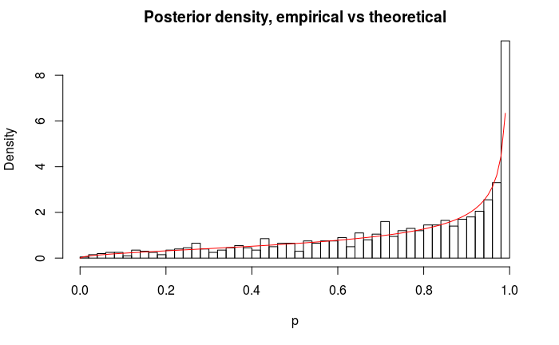

```r
psim = replicate(1000,simul_1(1/2,1/2,1))
hist(psim,50,freq = F,xlab = "p",main = "Posterior density, empirical vs theoretical")
curve(dbeta(x,3/2,1/2),add = T,col ="red")
```

Bon, ben ça marche bien !

2. Ben on peut tenter, juste en adaptant la fonction, mais on ajoute une condition d’arrêt au cas où (nombre max d’iterations)

```r
simul_1_bis = function(a,b,x1,itermax = 100000){
  keep = F
  i = 0
  while (!keep & i<itermax){
    p = rbeta(1,a,b)
    x = rbinom(length(x1),1,p)
    keep = prod(x==x1)
    i = i+1
  }
  if (i==itermax){
    warnings("Nombre d'itération maximal dépassé")
    return(-1)
  } else{
    return(p)
  }
}
simul_1_bis(1/2,1/2,c(1,1,0,1,1,0,0,1,1,1,1,1,0,1,1,0,0,1,1,1))
```

```
[1] -1
```

3. Comme on peut le voir en écrivant la densité, $S_n$ est une statistique exhaustive, i.e. la probabilité conditionnelle à $p$ et $S_n = s_n$ ne dépend plus de $p$, ou autrement dit, la probabilité s’écrit comme une fonction de $X$ fois une fonction de $p,s_n$ :

$$\mathbb{P}(X_1 = x_1, \cdots ,X_n = x_n\mid p ) = p^{s_n}(1-p)^{n-s_n}$$
En appliquant la formule de Bayes, on observe alors que

$$\pi(p \mid X = x) = \pi(p \mid S_n = s_n)$$

4. Il n’y a plus qu’à adapter la fonction qu’on a écrit (on garde la version avec un nombre maximal d’itérations.)

```r
simul_2 = function(a,b,n,s,itermax = 100000){
  keep = F
  i = 0
  while (!keep & i<itermax){
    p = rbeta(1,a,b)
    x = rbinom(n,1,p)
    keep = (sum(x)==s)
    i = i+1
  }
  if (i==itermax){
    warnings("Nombre d'itération maximal dépassé")
    return(-1)
  } else{
    return(p)
  }
}
simul_2(1/2,1/2,20,14)
```

```
[1] 0.7202017
```

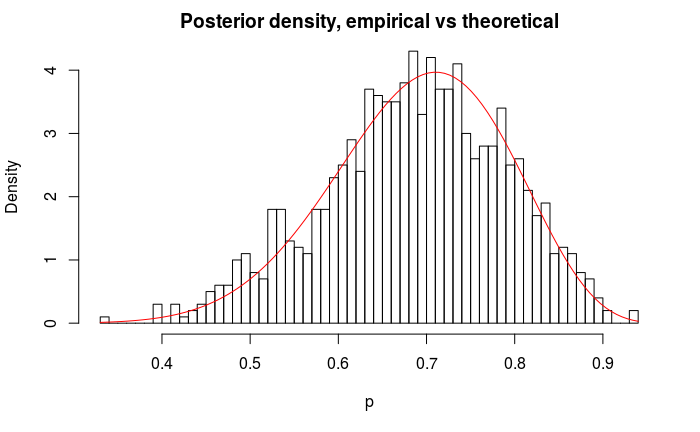

```r
psim = replicate(1000,simul_2(1/2,1/2,20,14))
hist(psim,50,freq = F,xlab = "p",main = "Posterior density, empirical vs theoretical")
curve(dbeta(x,1/2+14,1/2+6),add = T,col ="red")
```

5. Il suffit de changer la condition de rejet.

```r
rsimABC= function(a,b,n,s,epsilon,itermax = 100000){
  keep = F
  i = 0
  while (!keep & i<itermax){
    p = rbeta(1,a,b)
    x = rbinom(n,1,p)
    keep = (abs(sum(x)-s)<epsilon)
    i = i+1
  }
  if (i==itermax){
    warnings("Nombre d'itération maximal dépassé")
    return(-1)
  } else{
    return(p)
  }
}
rsimABC(1/2,1/2,1000,750,10)
```

```
[1] 0.7358759
```

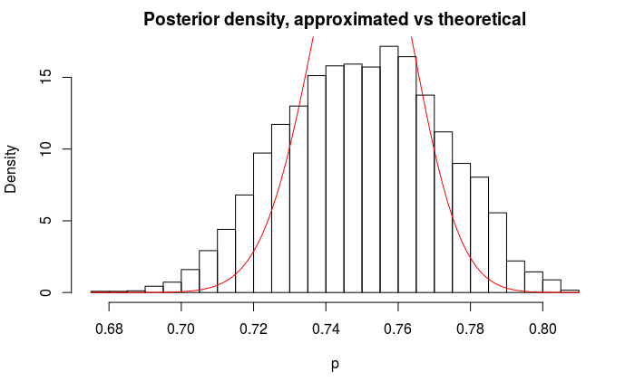

```r
psim = replicate(5000,rsimABC(1/2,1/2,1000,750,30))
hist(psim,40,freq = F,xlab = "p",main = "Posterior density, approximated vs theoretical")
curve(dbeta(x,1/2+750,1/2+250),add = T,col ="red")
```

On voit que l’on fait une approximation sur le posterior. C’est pourquoi en pratique, on évitera d’utiliser cet algo dès que l’on a beaucoup de données.

## Partie II : Métropolis Hasting pour un modèle de mélange.

L’objectif de ce TP est de traiter le cas d’un mélange gaussien (à deux composantes pour le moment).

On peut commencer par simuler un mélange pour travailler avec des données “faciles” :

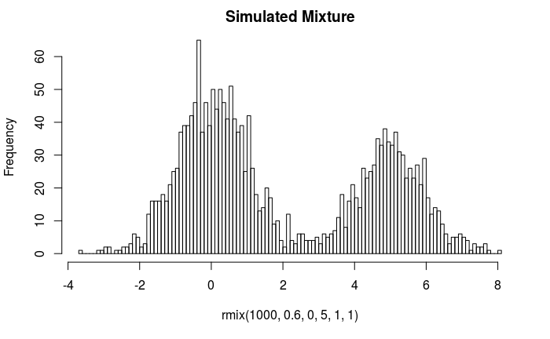

```r
rmix = function(N,p,moy1,moy2,t1,t2){
  N =2000
  b = rbinom(N,1,p)
  x = b*rnorm(N,moy1,1/t1)+(1-b)*rnorm(N,moy2,1/t2)
  return(x)
  }
hist(rmix(1000,0.6,0,5,1,1),100,main = "Simulated Mixture")
```

On va travailler avec le modèle suivant (tous les paramètres sont indépendants sous la loi apriori) :
$$\begin{align*}
p &\sim Beta(a_0,b_0)
\\ m_i &\sim \mathcal{N}\Big(\mu_0,\sigma_0^2\Big), i = 1, 2
\\ \tau_i &\sim Gamma(k_0,\lambda_0), i = 1,2
\\X_i|p,m,\tau &\sim_{i.i.d} p\mathcal{N}(m_1,\frac{1}{\tau_1})+(1-p)\mathcal{N}(m_2,\frac{1}{\tau_2})
\end{align*}$$

La dernière notation abusive explicite un mélange, i.e. tel que la densité de $X_i|p,m,$ s’écrit $f_{X|p,m,\tau}(x) = pf_{\mathcal{N}(m_1,\frac{1}{\tau_1})}(x)+(1-p)f_{\mathcal{N}(m_2,\frac{1}{\tau_2})}(x)$

Les hyperparamètres $(a_0,b_0,\mu_0,\sigma_0,k_0,\lambda_0)$ seront fixés plus tard.

Notre objectif est de mettre en place l’algorithme de Metropolis-Hasting sur ces données. Pour cela, on doit se donner des lois de propositions (données dans l’énoncé).

On peut dès lors coder le modèle :

```r
logvraiss= function(l,x){
  return(sum(log(l$p*dnorm(x,l$m1,1/sqrt(l$tau1))   +(1-l$p)*dnorm(x,l$m2,1/sqrt(l$tau2))   )))
}
logprior = function(l,hyperparam){
  return(log(dbeta(l$p,hyperparam$a,hyperparam$b))+log(dnorm(l$m1,hyperparam$mu,hyperparam$sig**2))+log(dnorm(l$m2,hyperparam$mu,hyperparam$sig**2))   +log(dgamma(l$tau1,hyperparam$k,hyperparam$lam))+log(dgamma(l$tau2,hyperparam$k,hyperparam$lam))  )
}
logpost = function(l,x,hyperparam){
  return(logvraiss(l,x)+logprior(l,hyperparam))
}
```

ainsi que les lois de proposition demandées :

```r
rprop = function(l,lsig =list(p = 1/100,m1 = 1/10,m2 = 1/10,tau1 = 1/100,tau2 = 1/100)){
  logratio = 0
  p = rbeta(1,1+l$p/lsig$p,1+(1-l$p)/lsig$p)
  logratio = logratio+log(dbeta(l$p,1+p/lsig$p,1+(1-p)/lsig$p))-log(dbeta(p,1+l$p/lsig$p,1+(1-l$p)/lsig$p))
  m1 = rnorm(1,l$m1,lsig$m1)
  m2 = rnorm(1,l$m2,lsig$m2)
  tau1 = rgamma(1,l$tau1/lsig$tau1,1/lsig$tau1)
  logratio = logratio+log(dgamma(l$tau1,tau1/lsig$tau1,1/lsig$tau1))-log(dgamma(tau1,l$tau1/lsig$tau1,1/lsig$tau1))
  tau2 = rgamma(1,l$tau2/lsig$tau2,1/lsig$tau2)
  logratio = logratio+log(dgamma(l$tau2,tau2/lsig$tau2,1/lsig$tau2))-log(dgamma(tau2,l$tau2/lsig$tau2,1/lsig$tau2))
  if (m1>m2){##pour l'identifiabilié, on demande en plus à ce que m_1<m_2
    provm = m1
    provtau = tau1
    tau1 = tau2
    m1 = m2
    m2 = provm
    tau2 = provtau
    p = 1-p
  }
  param = list(p = p,m1 = m1,m2 = m2,tau1 = tau1,tau2 = tau2)
  return(list(param = param,logratio = logratio))
}
```

Une fois ce travail effectué, il est facile de mettre en place MH. Attention, il faut initialiser intelligemment.

```r
stepMH = function(l,x,hyperparam,...){
  prop = rprop(l,...)
  lprop = prop$param
  di = logpost(lprop,x,hyperparam)-logpost(l,x,hyperparam) + prop$logratio
  if (log(runif(1))<di){
    lnew = lprop
  }  else{
    lnew = l
  }
  return(lnew)
}
init = function(x){
  tau1 = tau2 =1/var(x)
  m1 = m2 = mean(x)
  p =1/2
  return(list(p = p,m1 = m1,m2 = m2,tau1 = tau1,tau2 = tau2))
}
plot_run = function(x,mem,l,i = NULL,nbpoints = 10000){
    if (is.null(i)){i = dim(mem)[1]}
    par(mfrow = c(1,2))
    hist(x,100,freq= F,main = "Current estimated density")
    curve(l$p*dnorm(x,l$m1,1/sqrt(l$tau1)),add = T,col = "blue")
    curve((1-l$p)*dnorm(x,l$m2,1/sqrt(l$tau2)),add = T,col = "green")
    curve(l$p*dnorm(x,l$m1,1/sqrt(l$tau1))+(1-l$p)*dnorm(x,l$m2,1/sqrt(l$tau2)),add = T,col = "red")
    z1 = sample(i,nbpoints)
    z2 = sample(i,nbpoints)
    plot(z1,mem[z1,2]+2*1/sqrt(mem[z1,4])*runif(nbpoints,-1,1),ylim = range(x),col = "cyan",cex = 0.1,main = "MH trajectory with 2-sigma bands")
    points(z2,mem[z2,3]+2*1/sqrt(mem[z2,5])*runif(nbpoints,-1,1),ylim = range(x),col = "yellow",cex = 0.1)
    lines(1:i,mem[1:i,2],ylim = range(x),col = "blue")
    lines(1:i,mem[1:i,3],col = "green")
    }
runMH = function(x,hyperparam,nbstep,plo = F,paus = 1000,...){
  l = init(x)
  val0 = unlist(l)
  mem = matrix(NA,nbstep,length(val0))
  for (i in 1:nbstep){
    l = stepMH(l,x,hyperparam,...)
    mem[i,] = unlist(l)
    if (plo & (i%%paus==0)){##si on veut des graphes
      dev.off()
      par(mfrow = c(1,2))
      plot_run(x,mem,l)
      Sys.sleep(0.8)
    }
  }
  return(list(mem = mem,l = l))
}
```

Il ne reste plus qu’à faire tourner l’algo (on peut tester plusieurs paramètres):

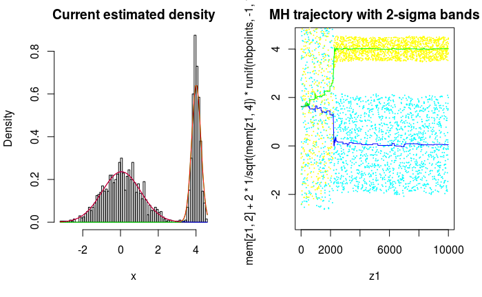

```r
hyperparam = list(a = 1/2,b = 1/2,mu = 0,sig = 100,k = 1,lam = 10)##on pourrait travailler pour choisir les priors non informatifs, ou alors utiliser de l'info exogène
lsig = list(p = 1/100,m1 =0.1,m2 = 0.1,tau1 = 1/10,tau2 = 1/10)##devrait être choisi pour avoir un bon taux de rejet. Les variances doivent  être du même ordre de grandeur que les quantités considérées
true = list(p = 0.6,m1 = 0,m2 = 4,tau1 =1,tau2 = 5)##pour la simulation
x = rmix(1000,true$p,true$m1,true$m2,true$tau1,true$tau2)
r = runMH(x,hyperparam,10000,plo = F,paus = 0,lsig)
plot_run(x,r$mem,r$l,i = NULL,nbpoints = 2000)
```

Sur le dernier graphique, on peut observer le temps avant convergence.

On peut modifier les paramètres de lsig, pour modifier ce temps là. Idéalement, il faudrait les calibrer pour la bonne proportion de rejets.

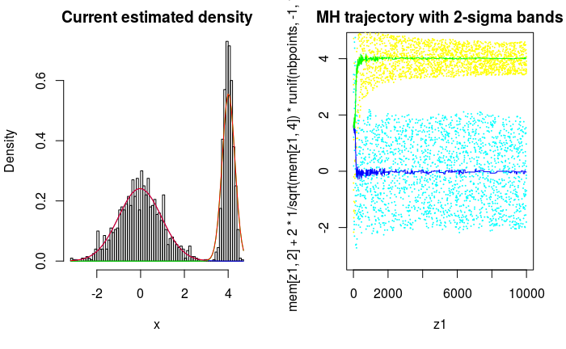

```r
lsig = list(p = 1/1000,m1 =0.2,m2 = 0.2,tau1 = 1/1000,tau2 = 1/1000)##devrait être choisi pour avoir un bon taux de rejet. Les variances doivent  être du même ordre de grandeur que les quantités considérées
true = list(p = 0.6,m1 = 0,m2 = 4,tau1 =1,tau2 = 5)##pour la simulation
x = rmix(1000,true$p,true$m1,true$m2,true$tau1,true$tau2)
r = runMH(x,hyperparam,10000,plo = F,paus = 0,lsig)
plot_run(x,r$mem,r$l,i = NULL,nbpoints = 2000)
```

On peut aussi calculer les moyennes a posteriori (à comparer avec les vrais paramètres).

```r
post_mean = apply(r$mem[-(1:1000),],2,"mean")
m = rbind(unlist(true),post_mean)
rownames(m) = c("Vrai","Espérances à posteriori")
print(round(m,digits = 2))
```

```
                          p    m1   m2 tau1 tau2
Vrai                    0.6  0.00 4.00 1.00 5.00
Espérances à posteriori 0.6 -0.02 4.01 0.97 8.95
```

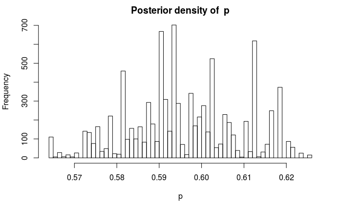

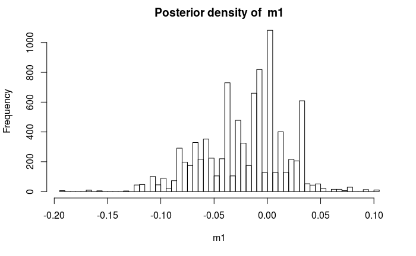

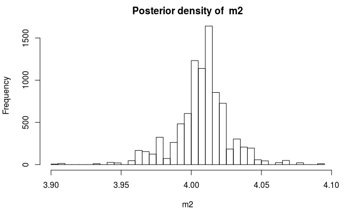

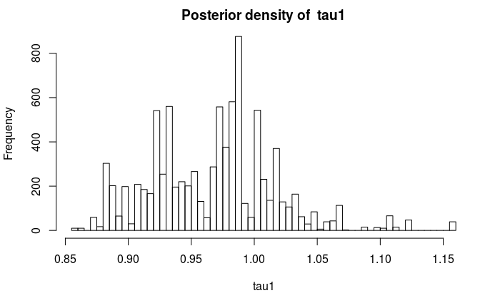

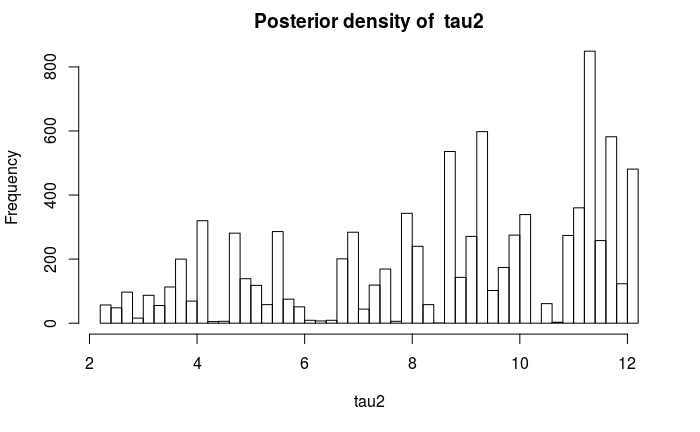

```r
r = runMH(x,hyperparam,10000,plo = F,paus = 0,lsig)
nam =c("p","m1","m2","tau1","tau2")
for (i in 1:ncol(r$mem)){
  hist((r$mem[-(1:1000),i]),50,main =paste("Posterior density of ", nam[i]),xlab = nam[i])
}
```

[figure not shown]

On voit ici qu’il faut prendre en compte d’autres paramètres, pour vraiment avoir une région de crédibilité HPD (ici on voit des points bleu au milieu des points rouges, ce qui est du au fait que l’on regarde la projection d’une région).

A vous d’explorer cela avec de vraies données….

**Remarque importante :** En conclusion, on peut retenir qu’il reste le problème de la calibration de la loi de proposition. En réalité, proposer de modifier toutes les variables simultanément est plutôt problématique : si l’une seule des variables est bien moins probable sous le posterior, alors on devra toutes les jeter. Cela motive la dernière version de simulation du posterior : l’algorithme de Gibbs !